# Smart_Trader

## Actor Critic Model

Scenario 2

```python
#reference text
#https://books.google.com.sg/books?id=HnetDwAAQBAJ&pg=PT710&lpg=PT710&dq=replay+buffer+keras&source=bl&ots=kOYzzExOB5&sig=ACfU3U3A3YbvM4DuqReHvK1aYEtiDIpKUQ&hl=en&sa=X&ved=2ahUKEwiLtoHTk6zpAhXbeisKHUpCDkoQ6AEwA3oECAgQAQ#v=onepage&q=replay%20buffer%20keras&f=false
#https://towardsdatascience.com/how-to-train-your-quadcopter-adventures-in-machine-learning-algorithms-e6ee5033fd61
#https://towardsdatascience.com/understanding-and-implementing-distributed-prioritized-experience-replay-horgan-et-al-2018-d2c1640e0520
#https://github.com/PacktPublishing/Python-Reinforcement-Learning-Projects
#https://github.com/germain-hug/Deep-RL-Keras
```

```python
from keras import layers, models, optimizers,regularizers,initializers
from keras import backend as K
import numpy as np
import pandas as pd
from numpy.random import choice
import random
from collections import namedtuple,deque
import math
import matplotlib.pyplot as plt
```

## Understand Data

```python
train_path =  'data/SPY_training.csv'
test_path = 'data/SPY_test.csv'
```

```python
df_train = pd.read_csv(train_path)
df_test = pd.read_csv(test_path)
```

```python
df = df_train.append(df_test)
# Convert Date column to datetime
df.loc[:, 'Date'] = pd.to_datetime(df['Date'],format='%Y-%m-%d')
# Remove spacing from columns headers
df.columns = [str(x).replace(' ', '_') for x in df.columns]
# Sort by datetime
df.sort_values(by='Date', inplace=True, ascending=True)
df.head(5)
```

|  | Date | Open | High | Low | Close | Adj_Close | Volume |
| --- | --- | --- | --- | --- | --- | --- | --- |
| 0 | 1993-01-29 | 43.96875 | 43.96875 | 43.75000 | 43.93750 | 26.299288 | 1003200 |
| 1 | 1993-02-01 | 43.96875 | 44.25000 | 43.96875 | 44.25000 | 26.486324 | 480500 |
| 2 | 1993-02-02 | 44.21875 | 44.37500 | 44.12500 | 44.34375 | 26.542448 | 201300 |
| 3 | 1993-02-03 | 44.40625 | 44.84375 | 44.37500 | 44.81250 | 26.822998 | 529400 |
| 4 | 1993-02-04 | 44.96875 | 45.09375 | 44.46875 | 45.00000 | 26.935240 | 531500 |

```python
print("the date range of training dataset: ",df_train['Date'].min(), df_train['Date'].max())
print("the date range of test dataset: ",df_test['Date'].min(), df_test['Date'].max())
```

```
the date range of training dataset:  1993-01-29 2018-12-31
the date range of test dataset:  2019-01-02 2020-05-08
```

```python
print("the size of training dataset: ", df_train.shape)
print("the size of test dataset: ",df_test.shape)
print ("the size of complete dataset: ",df.shape)
```

```
the size of training dataset:  (6528, 7)
the size of test dataset:  (341, 7)
the size of complete dataset:  (6869, 7)
```

```python
print(df. describe())
```

```
              Open         High          Low        Close    Adj_Close  \
count  6869.000000  6869.000000  6869.000000  6869.000000  6869.000000
mean    139.093952   139.916955   138.182487   139.093162   114.767321
std      65.539873    65.795507    65.266381    65.548151    70.531779
min      43.343750    43.531250    42.812500    43.406250    25.981276
25%      98.580002    99.489998    97.470001    98.519997    71.126038
50%     126.250000   127.080002   125.330002   126.160004    93.850166
75%     165.600006   166.309998   164.860001   165.740005   144.523026
max     337.790009   339.079987   337.480011   338.339996   336.362091

             Volume
count  6.869000e+03
mean   8.476451e+07
std    9.771849e+07
min    5.200000e+03
25%    7.437300e+06
50%    5.766680e+07
75%    1.225063e+08
max    8.710263e+08
```

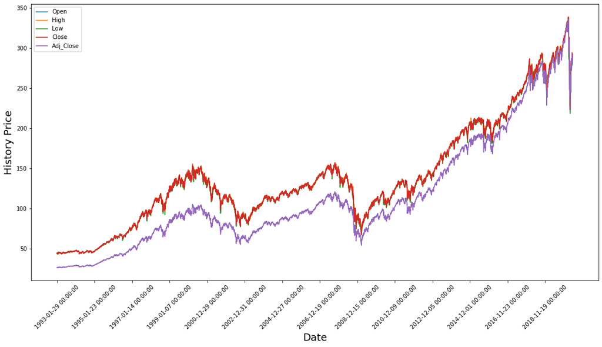

```python
plt.figure(figsize = (18,9))
plt.plot(range(df.shape[0]),(df['Open']))
plt.plot(range(df.shape[0]),(df['High']))
plt.plot(range(df.shape[0]),(df['Low']))
plt.plot(range(df.shape[0]),(df['Close']))
plt.plot(range(df.shape[0]),(df['Adj_Close']))
plt.xticks(range(0,df.shape[0],500),df['Date'].loc[::500],rotation=45)
plt.xlabel('Date',fontsize=18)
plt.ylabel('History Price',fontsize=18)
plt.legend(['Open','High','Low','Close','Adj_Close'], loc='upper left')
plt.show()
```

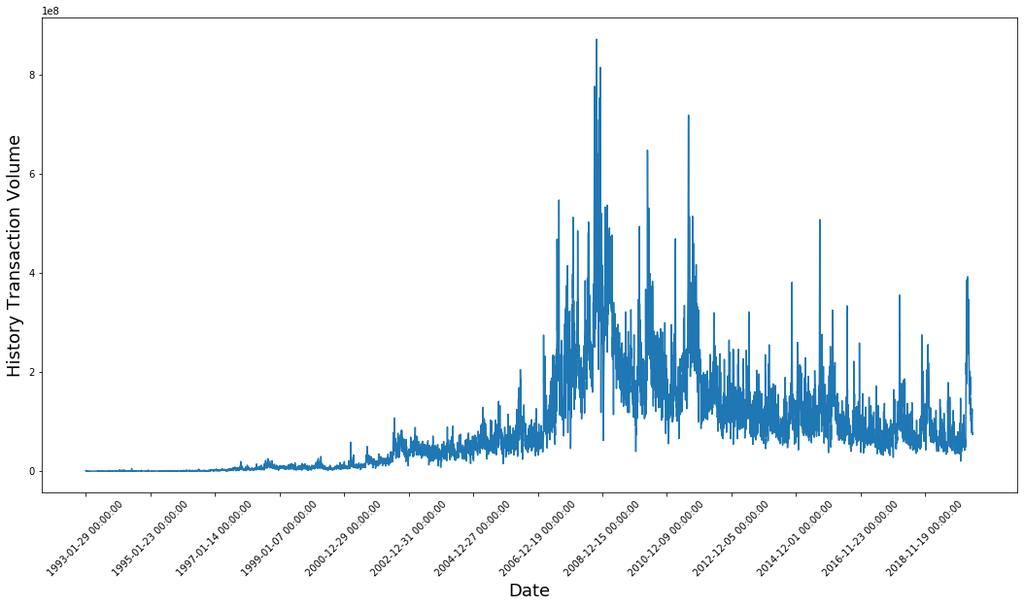

```python
plt.figure(figsize = (18,9))
plt.plot(range(df.shape[0]),(df['Volume']))
plt.xticks(range(0,df.shape[0],500),df['Date'].loc[::500],rotation=45)
plt.xlabel('Date',fontsize=18)
plt.ylabel('History Transaction Volume',fontsize=18)
plt.show()
```

The trend of open, high, low, close and adj close is similar

It seems when there is a price drop, there is a volume surge

```python
print("checking if any null values are present\n", df.isna().sum())
```

```
checking if any null values are present
 Date         0
Open         0
High         0
Low          0
Close        0
Adj_Close    0
Volume       0
dtype: int64
```

#### Actor Network

Purpose: Define the actor (policy) model.The actor could be a neural network taking observations (states) as inputs and outputting one possible action.

Possible Improvements: Policy Search Improvement: When the policy space is big,finding a good set of parameters via brute force search is diffcult, in that case genetic algorithm can be used for more efficient policy search. Example: create a first generation of 100 random policies, evaluate their performance and remove 80 bad policies.Then make the surviving policies to cross-over and mutate to produce the second generation. Then the process iterates until an acceptable solution is found.

```python
#the aim of the training is to maximise the discounted accumulative rewards & minimise the negatives of Q-value
#could switch the model to keras sequential model
class Actor:
    def __init__(self, state_size, action_size):
        self. state_size = state_size
        self. action_size = action_size
        self. build_model()

    def build_model(self):
        #add states as the inputs
        states = layers.Input(shape=(self.state_size,), name='states')
        #dimensionality of the first output space=16 (16 neurons)
        net = layers.Dense(units=16,kernel_regularizer=regularizers.l2(1e-6))(states)
        net = layers.BatchNormalization()(net) #Normalize and scale inputs which allows each layer of a network to learn by itself a little bit more independently of other layers
        net = layers.Activation("relu")(net)
        #dimensionality of the second output space= 32 (32 neurons)
        net = layers.Dense(units=32,kernel_regularizer=regularizers.l2(1e-6))(net)
        net = layers.BatchNormalization()(net)
        net = layers.Activation("relu")(net)
        #dimensionality of the third output space= number of possible actions, each action is predicted with an probability
        actions = layers.Dense(units=self.action_size, activation='softmax', name = 'actions')(net)
        #the models class groups layers into an object with training and inference features.
        self.model = models.Model(inputs=states, outputs=actions)
        #model.save('data/actor_model')
        #define the loss function by using the action value (Q_value) gradients, for policy evaluation
        action_gradients = layers.Input(shape=(self.action_size,))
        loss = K.mean(-action_gradients * actions) #the aims is to minimise the negatives of Q-values
        #define the optimizer and train the function
        optimizer = optimizers.Adam(lr=.0001)
        updates_op = optimizer.get_updates(params=self.model.trainable_weights, loss=loss)
        self.train_fn = K.function(inputs=[self.model.input, action_gradients, K.learning_phase()],outputs=self.model.output,updates=updates_op)
```

#### Critic Network

Purpose: Build a critic (value) network that maps state and action pairs (Q_values)

```python
class Critic:
    def __init__(self, state_size, action_size):
        self.state_size = state_size
        self.action_size = action_size
        self.build_model()

    def build_model(self):
        states = layers.Input(shape=(self.state_size,), name='states')
        actions = layers.Input(shape=(self.action_size,), name='actions')
        net_states = layers.Dense(units=16,kernel_regularizer=regularizers.l2(1e-6))(states)
        net_states = layers.BatchNormalization()(net_states)
        net_states = layers.Activation("relu")(net_states)
        #two inputs dense to same shapes
        net_states = layers.Dense(units=32, kernel_regularizer=regularizers.l2(1e-6))(net_states)
        net_actions = layers.Dense(units=32,kernel_regularizer=regularizers.l2(1e-6))(actions)
        #add the two inputs
        net = layers.Add()([net_states, net_actions])
        net = layers.Activation('relu')(net)
        #the final output layer will produce the Q-value state -action value
        Q_values = layers.Dense(units=1, name='q_values',kernel_initializer=initializers.RandomUniform(minval=-0.003, maxval=0.003))(net)
        self.model = models.Model(inputs=[states, actions], outputs=Q_values)
        optimizer = optimizers.Adam(lr=0.0001)
        self.model.compile(optimizer=optimizer, loss='mse')
        action_gradients = K.gradients(Q_values, actions)
        self.get_action_gradients = K.function(inputs=[*self.model.input, K.learning_phase()],outputs=action_gradients)
```

#### Agent

Purpose: define an agent to train the actor and critic

```python
'''instead of training the DQN on the latest experiences, we will store all experiences in a replay buffer
   or a replay memory and we will sample a random training from it at each training iteration. This helps to reduce
   the correlation between the experiences in a training batch, which tremendously help training.
'''
# prioritized Experience Replay /importance sampling (sample important experiences more frequently)
#https://towardsdatascience.com/understanding-and-implementing-distributed-prioritized-experience-replay-horgan-et-al-2018-d2c1640e0520

class ReplayBuffer:
    def __init__(self, buffer_size, batch_size):
        self.memory = deque(maxlen=buffer_size)
        self.batch_size = batch_size
        self.experience = namedtuple("Experience", field_names=["state", "action", "reward", "next_state", "done"])
    #Add a new experience to the replay buffer memory
    def add(self, state, action, reward, next_state, done):
        e = self.experience(state, action, reward, next_state, done)
        self.memory.append(e)
    # randomly sample states from a memory buffer to improve overfitting
    def sample(self, batch_size=32):
        return random.sample(self.memory, k=self.batch_size)
    #Return the current size of the buffer memory
    def __len__(self):
        return len(self.memory)
```

Possible Improvements: Policy Gradient

```python
#learns via actor and agent networks
class Agent:
    def __init__(self, state_size, batch_size, is_eval = False):
        #replay memory size
        self.state_size = state_size
        self.action_size = 3 #3 actions: buy, sell, hold
        self.buffer_size = 1000000
        self.batch_size = batch_size
        self.memory = ReplayBuffer(self.buffer_size, self.batch_size)
        self.inventory = []
        self.share= []
        #whether or not training is ongoing. This variable will be changed during the training and evaluation phase
        self.is_eval = is_eval
        #discount factor in Bellman equation
        self.gamma = 0.99
        #a soft update of the actor and critic networks
        self.tau = 0.001
        #the actor policy model maps states to actions
        self.actor_local = Actor(self.state_size, self.action_size)
        self.actor_target = Actor(self.state_size, self.action_size)
        self.actor_target.model.set_weights(self.actor_local.model.get_weights()) #sets the target model parameters to local model parameters
        #the critic (value) model  maps the state-action pairs to Q_values
        self.critic_local = Critic(self.state_size, self.action_size)
        self.critic_target = Critic(self.state_size, self.action_size)
        self.critic_target.model.set_weights(self.critic_local.model.get_weights())

    #the function will return the actions with probability distributions, given a state, using the actor (policy) network
    #the action with highest probability is the best action to given the state (best action to take)
    def act(self, state):
        options = self.actor_local.model.predict(state)
        self.last_state = state
        if not self.is_eval:
            return choice(range(3), p = options[0])
        return np.argmax(options[0])

    #the function will assign a stochastic policy, based on the action probabilities in the training model
    #the function will assign a deterministic action corresponding to the maximum probability in the testing model
    #the function will return the set of actions carried by the agent in each episode (all steps are recorded)
    def step(self, action, reward, next_state, done):
        self.memory.add(self.last_state, action, reward, next_state, done) #adds a new experience to the memory
        if len(self.memory) > self.batch_size: #when enough experiences are presented in memory for training
            experiences = self.memory.sample(self.batch_size)# a ranfom sample will be pulled for training
            self.learn(experiences) #the agent then learns from the sample experience
            self.last_state = next_state #update the state to next state

    #the function will learned the sampled experiences through the actor and the critic
    def learn(self, experiences):
        states = np.vstack([e.state for e in experiences if e is not None]).astype(np.float32).reshape(-1,self.state_size)
        actions = np.vstack([e.action for e in experiences if e is not None]).astype(np.float32).reshape(-1,self.action_size)
        rewards = np.array([e.reward for e in experiences if e is not None]).astype(np.float32).reshape(-1,1)
        dones = np.array([e.done for e in experiences if e is not None]).astype(np.float32).reshape(-1,1)
        next_states = np.vstack([e.next_state for e in experiences if e is not None]).astype(np.float32).reshape(-1,self.state_size)

        actions_next = self.actor_target.model.predict_on_batch(next_states)
        Q_targets_next = self.critic_target.model.predict_on_batch([next_states, actions_next])

        Q_targets = rewards + self.gamma * Q_targets_next * (1 - dones)
        self.critic_local.model.train_on_batch(x = [states, actions], y=Q_targets)

        action_gradients = np.reshape(self.critic_local.get_action_gradients([states, actions, 0]),(-1, self.action_size))
        self.actor_local.train_fn([states, action_gradients, 1])
        self.soft_update(self.critic_local.model, self.critic_target.model)
        self.soft_update(self.actor_local.model, self.actor_target.model)

    #the function performs soft updates on the model parameters to avoid drastic model changes
    def soft_update(self, local_model, target_model):
        local_weights = np.array(local_model.get_weights())
        target_weights = np.array(target_model.get_weights())

        assert len(local_weights) == len(target_weights)

        new_weights = self.tau * local_weights + (1 - self.tau) * target_weights
        target_model.set_weights(new_weights)
```

#### Utility Functions

```python
#utility functions
def formatPrice(n):
    if n >= 0:
        curr = "$"
    else:
        curr = "-$"
    return curr + "{0:.2f}".format(abs(n))


def getStockData(key):
    datavec = []
    lines = open("data/" + key + ".csv", "r").read().splitlines()

    for line in lines[1:]:
        datavec.append(float(line.split(",")[4]))

    return datavec

#The function for this takes three parameters: the data; a time, t (the day that you want to predict);
#and a window (how many days to go back in time)
def getState(data, t, window):
    if t - window >= -1:
        vec = data[t - window + 1:t + 1]
    else:
        vec = -(t-window+1)*[data[0]]+data[0: t + 1]
    #Nscale the state vector from 0 to 1 with a sigmoid function.
    #The sigmoid function can map any input value, from 0 to 1. This helps to normalize the values to probabilities.
    scaled_state = []
    for i in range(window - 1):
        scaled_state.append(1/(1 + math.exp(vec[i] - vec[i+1])))

    return np.array([scaled_state])
```

#### Train and Test

```python
window_size = 100
batch_size = 32
agent = Agent(window_size, batch_size)
df_train = getStockData("SPY_training")
len_train = len(df_train) - 1
episode_count = 150
summary = []

for e in range(episode_count):
    print("Episode " + str(e) + "/" + str(episode_count))
    state = getState(df_train, 0, window_size + 1) #first state in an epsiode
    agent.inventory = []
    agent.share =[]
    initial_amount = 50000
    final_amount = 50000
    total_profit = 0
    done = False

    for t in range(len_train):
        action = agent.act(state)
        action_prob = agent.actor_local.model.predict(state)
        next_state = getState(df_train, t + 1, window_size + 1)
        reward = 0

        #every day, agent has to decide an action: buy,sell or hold
        #if action==0, there is no action needed to be carried out (hold the stock)
        #if the action =1, buy the stock on the day, the quantity is always set to 1
        if action == 1 and final_amount >= df_train[t]*500:
            agent.inventory.append(df_train[t])
            share = 500 #TODO: Setup a new policy to guide the amount of share to buy
            agent.share.append(share)
            commission_cost = max(1, share*df_train[t]*0.001)
            final_amount = final_amount - df_train[t]*share - commission_cost
            print("At timestep " + str(t) + ", Buy: " + formatPrice(df_train[t])+ "* 500" + ", Balance= " + str (final_amount))
        #if the action ==2, sell some of the stocks bought previously
        elif action == 2 and len(agent.inventory) > 0:
            bought_price = agent.inventory.pop(0)
            #reward = max(df_train[t] - bought_price, 0)
            bought_share = agent.share.pop(0)
            profit = df_train[t]*bought_share - bought_price*bought_share
            commission_cost = max(1, bought_share*df_train[t]*0.001)
            reward = max(profit-commission_cost*2,0) #service charge buy & service charge sell
            final_amount = final_amount + df_train[t]*bought_share -commission_cost
            print("At timestep " + str(t) + ", Sell: " + formatPrice(df_train[t])+ "* 500"+ ", Profit: " + formatPrice(profit - commission_cost*2) + ", Balance= " + str (final_amount))
        else:
            pass

        if (t == len_train - 1) or (final_amount <= 0 and len(agent.inventory) <= 0 ):
            done = True

        agent.step(action_prob, reward, next_state, done)
        state = next_state

        if done == True:
            #TODO: to implement the function in a more elegant manner, to sold out whatever left at terminal state
            if len(agent.inventory) > 0:
                for i in range (len(agent.inventory)-1):
                    bought_price = agent.inventory.pop(0)
                    bought_share = agent.share.pop(0)
                    profit = df_train[t]*bought_share - bought_price*bought_share
                    commission_cost = max(1, bought_share*df_train[t]*0.001)
                    final_amount = final_amount + df_train[t]*bought_share -commission_cost
            if final_amount > 0:
                total_profit = final_amount - initial_amount
            else:
                total_profit = final_amount + initial_amount
            print("------------------------------------------")
            print("Final Amount: " + formatPrice(final_amount))
            print("Total Profit/Loss: " + formatPrice(total_profit))
            print("------------------------------------------")
            summary.append(total_profit)
            print(summary)
            break
```

[output not shown]

[output cut: 3195 more lines]

```
At timestep 0, Buy: $43.94* 500, Balance= 28009.28125
At timestep 1, Buy: $44.25* 500, Balance= 5862.15625
------------------------------------------
Final Amount: $129613.28
Total Profit/Loss: $79613.28
------------------------------------------
[3875.4671819999494, -48539.103494499956, 78533.53374949998, 79613.28125, 79613.28125, 79613.28125, 76451.6317485, 76837.61711650001, 77079.5, 0, 0, 0, 0, 0, 0, 78390.5436865, 79341.0390625, 79613.28125, 79613.28125, 79613.28125, 79613.28125, 79613.28125, 79613.28125, 79613.28125, 79613.28125, 79613…
Episode 149/150
At timestep 0, Buy: $43.94* 500, Balance= 28009.28125
At timestep 1, Buy: $44.25* 500, Balance= 5862.15625
------------------------------------------
Final Amount: $129613.28
Total Profit/Loss: $79613.28
------------------------------------------
[3875.4671819999494, -48539.103494499956, 78533.53374949998, 79613.28125, 79613.28125, 79613.28125, 76451.6317485, 76837.61711650001, 77079.5, 0, 0, 0, 0, 0, 0, 78390.5436865, 79341.0390625, 79613.28125, 79613.28125, 79613.28125, 79613.28125, 79613.28125, 79613.28125, 79613.28125, 79613.28125, 79613…
```

```python
df_test = getStockData("SPY_test")
len_test = len(df_test) - 1
state = getState(df_test, 0, window_size + 1)
total_profit = 0
agent.inventory = []
agent.share = []
agent.is_eval = False
done = False
summary_test = []
initial_amount = 50000
final_amount = 50000

for t in range(len_test):
    action = agent.act(state)
    next_state = getState(df_test, t + 1, window_size + 1)
    reward = 0

    if action == 1 and (final_amount >= df_test[t]*100):
        agent.inventory.append(df_test[t])
        share = 100 #TODO: Setup a new policy to guide the amount of share to buy
        agent.share.append(share)
        commission_cost = max(1, share*df_test[t]*0.001)
        final_amount = final_amount - df_test[t]*share - commission_cost
        print("At timestep " + str(t) + ", Buy: " + formatPrice(df_test[t])+ "* 100" + ", Balance= " + str (final_amount))
    elif action == 2 and len(agent.inventory) > 0:
        bought_price = agent.inventory.pop(0)
        bought_share = agent.share.pop(0)
        profit = df_test[t]*bought_share - bought_price*bought_share
        commission_cost = max(1, bought_share*df_test[t]*0.001)
        reward = max(profit-commission_cost*2,0) #service charge buy & service charge sell
        final_amount = final_amount + df_test[t]*bought_share -commission_cost
        #profit at buy and sell
        print("At timestep " + str(t) + ", Sell: " + formatPrice(df_test[t])+ "* 100"+ ", Profit: " + formatPrice(profit - commission_cost*2) + ", Balance= " + str (final_amount))
    else:
        pass

    summary_test.append(final_amount)

    if (t == len_test - 1) or (final_amount <= 0 and len(agent.inventory) <= 0):
        done = True

    agent.step(action_prob, reward, next_state, done)
    state = next_state

    if done:
        if len(agent.inventory) > 0:
            for i in range (len(agent.inventory)-1):
                bought_price = agent.inventory.pop(0)
                bought_share = agent.share.pop(0)
                commission_cost = max(1, bought_share*df_train[t]*0.001)
                final_amount = final_amount + df_test[t]*bought_share -commission_cost
                summary_test.append(final_amount)
        if final_amount > 0:
                total_profit = final_amount - initial_amount
        else:
            total_profit = final_amount + initial_amount
        print("------------------------------------------")
        print("Final Amount: " + formatPrice(final_amount))
        print("Total Profit: " + formatPrice(total_profit))
        print("------------------------------------------")
        break
```

```
At timestep 0, Buy: $250.18* 100, Balance= 24956.982700700002
At timestep 1, Buy: $244.21* 100, Balance= 511.5610000000017
------------------------------------------
Final Amount: $29274.94
Total Profit: -$20725.06
------------------------------------------
```

```python
print (summary)
```

```
[3875.4671819999494, -48539.103494499956, 78533.53374949998, 79613.28125, 79613.28125, 79613.28125, 76451.6317485, 76837.61711650001, 77079.5, 0, 0, 0, 0, 0, 0, 78390.5436865, 79341.0390625, 79613.28125, 79613.28125, 79613.28125, 79613.28125, 79613.28125, 79613.28125, 79613.28125, 79613.28125, 79613…
```

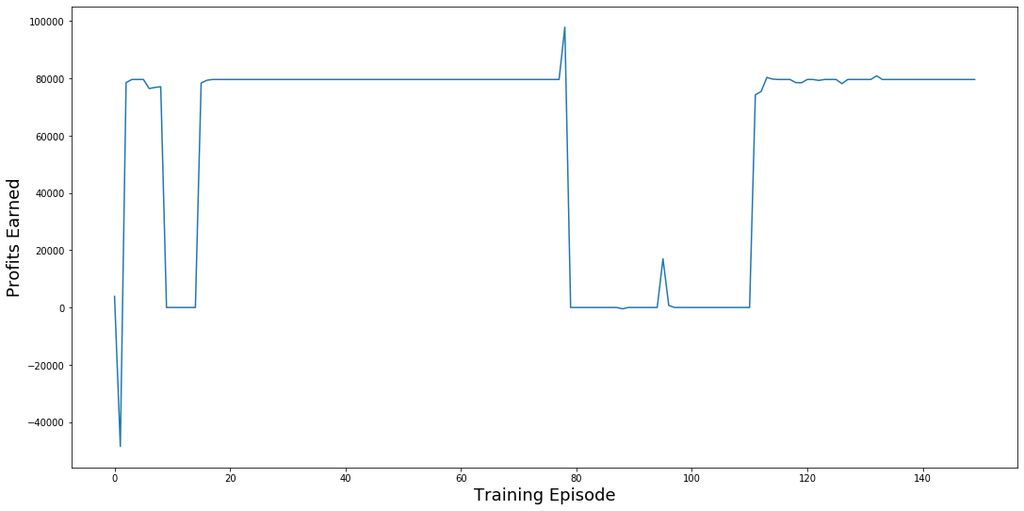

```python
plt.figure(figsize = (18,9))
plt.plot(summary) # plotting by columns
plt.xlabel('Training Episode',fontsize=18)
plt.ylabel('Profits Earned',fontsize=18)
plt.show()
```

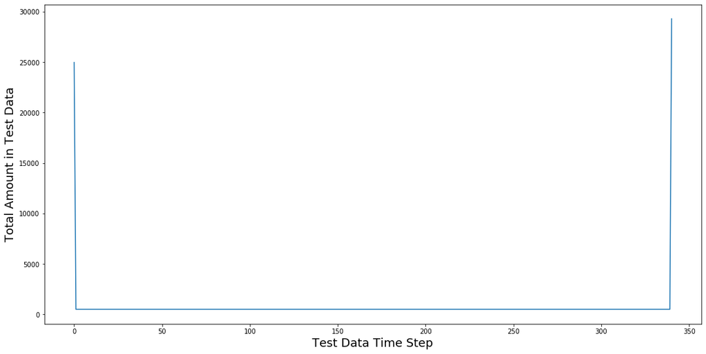

```python
plt.figure(figsize = (18,9))
plt.plot(summary_test) # plotting by columns
plt.xlabel('Test Data Time Step',fontsize=18)
plt.ylabel('Total Amount in Test Data',fontsize=18)
plt.show()
```